# Risk Factor Analysis

## Outcome Variable

**Outcome Variable:** haz

## Predictor Variables

**Intervention Variable:** hfoodsec

**Adjustment Set:**

- arm
- sex
- W_mage
- meducyrs
- feducyrs
- hhwealth_quart
- vagbrth
- W_nrooms
- W_nchldlt5
- brthmon
- W_parity
- impfloor
- impsan
- safeh20
- delta_W_mage
- delta_meducyrs
- delta_feducyrs
- delta_hhwealth_quart
- delta_vagbrth
- delta_W_nrooms
- delta_W_nchldlt5
- delta_brthmon
- delta_W_parity
- delta_impfloor
- delta_impsan
- delta_safeh20

## Stratifying Variables

The analysis was stratified on these variable(s):

- agecat

## Data Summary

| agecat | hfoodsec | n_cell | n | outcome_variable |
| --- | --- | --- | --- | --- |
| Birth | Food Secure | 9647 | 19616 | haz |
| Birth | Mildly Food Insecure | 6730 | 19616 | haz |
| Birth | Food Insecure | 3239 | 19616 | haz |
| 6 months | Food Secure | 12363 | 24383 | haz |
| 6 months | Mildly Food Insecure | 8109 | 24383 | haz |
| 6 months | Food Insecure | 3911 | 24383 | haz |
| 24 months | Food Secure | 7621 | 15346 | haz |
| 24 months | Mildly Food Insecure | 5065 | 15346 | haz |
| 24 months | Food Insecure | 2660 | 15346 | haz |

The following strata were considered:

- agecat: 24 months
- agecat: 6 months
- agecat: Birth

## Methods Detail

We’re interested in the causal parameters $E[Y_a]$ for all values of $a \in \mathcal{A}$. These parameters represent the mean outcome if, possibly contrary to fact, we intervened to set all units to have $A=a$. Under the randomization and positivity assumptions, these are identified by the statistical parameters $\psi_a=E_W[E_{Y|A,W}(Y|A=a,W)]$. In addition, we’re interested in the mean of $Y$, $E[Y]$ under no intervention (the observed mean). We will estimate these parameters by using SuperLearner to fit the relevant likelihood factors – $E_{Y|A,W}(Y|A=a,W)$ and $p(A=a|W)$, and then updating our likelihood fit using a joint TMLE.

For unadjusted analyses ($W=\{\}$), initial likelihoods were estimated using Lrnr_glm to estimate the simple $E(Y|A)$ and Lrnr_mean to estimate $p(A)$. For adjusted analyses, a small library containing Lrnr_glmnet, Lrnr_xgboost, and Lrnr_mean was used.

Having estimated these parameters, we will then use the delta method to estimate relative risks and attributable risks relative to a prespecified baseline level of $A$.

# Results Detail

## Results Plots

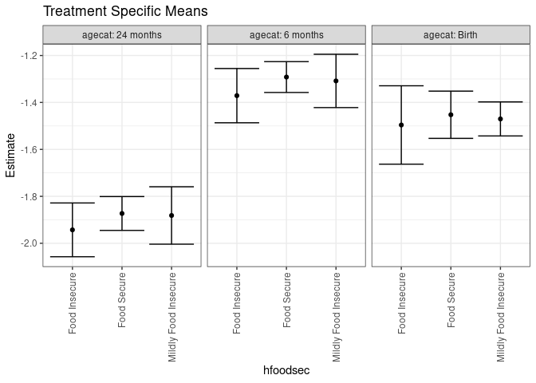

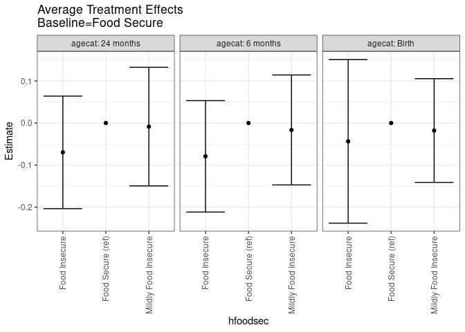

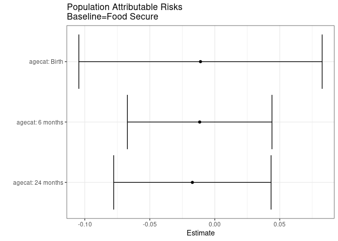

## Results Table

### Parameter: TSM

| agecat | intervention_level | baseline_level | estimate | ci_lower | ci_upper |
| --- | --- | --- | --- | --- | --- |
| Birth | Food Secure | NA | -1.452409 | -1.553026 | -1.351792 |
| Birth | Mildly Food Insecure | NA | -1.470282 | -1.542767 | -1.397797 |
| Birth | Food Insecure | NA | -1.496026 | -1.662983 | -1.329068 |
| 6 months | Food Secure | NA | -1.291850 | -1.357561 | -1.226139 |
| 6 months | Mildly Food Insecure | NA | -1.308339 | -1.421967 | -1.194710 |
| 6 months | Food Insecure | NA | -1.371043 | -1.486610 | -1.255476 |
| 24 months | Food Secure | NA | -1.872997 | -1.945091 | -1.800903 |
| 24 months | Mildly Food Insecure | NA | -1.881538 | -2.003861 | -1.759214 |
| 24 months | Food Insecure | NA | -1.942817 | -2.057353 | -1.828282 |

### Parameter: E(Y)

| agecat | intervention_level | baseline_level | estimate | ci_lower | ci_upper |
| --- | --- | --- | --- | --- | --- |
| Birth | NA | NA | -1.463397 | -1.501666 | -1.425128 |
| 6 months | NA | NA | -1.303465 | -1.337911 | -1.269018 |
| 24 months | NA | NA | -1.890230 | -1.928146 | -1.852314 |

### Parameter: ATE

| agecat | intervention_level | baseline_level | estimate | ci_lower | ci_upper |
| --- | --- | --- | --- | --- | --- |
| Birth | Food Secure | Food Secure | 0.0000000 | 0.0000000 | 0.0000000 |
| Birth | Mildly Food Insecure | Food Secure | -0.0178728 | -0.1411661 | 0.1054204 |
| Birth | Food Insecure | Food Secure | -0.0436166 | -0.2380474 | 0.1508143 |
| 6 months | Food Secure | Food Secure | 0.0000000 | 0.0000000 | 0.0000000 |
| 6 months | Mildly Food Insecure | Food Secure | -0.0164885 | -0.1471697 | 0.1141928 |
| 6 months | Food Insecure | Food Secure | -0.0791929 | -0.2116330 | 0.0532471 |
| 24 months | Food Secure | Food Secure | 0.0000000 | 0.0000000 | 0.0000000 |
| 24 months | Mildly Food Insecure | Food Secure | -0.0085402 | -0.1495088 | 0.1324283 |
| 24 months | Food Insecure | Food Secure | -0.0698199 | -0.2035978 | 0.0639580 |

### Parameter: PAR

| agecat | intervention_level | baseline_level | estimate | ci_lower | ci_upper |
| --- | --- | --- | --- | --- | --- |
| Birth | Food Secure | NA | -0.0109881 | -0.1045773 | 0.0826011 |
| 6 months | Food Secure | NA | -0.0116147 | -0.0672103 | 0.0439810 |
| 24 months | Food Secure | NA | -0.0172329 | -0.0777671 | 0.0433014 |